## `scattergeo` - Interactive Scatter Plot Maps

### Plotting NOAA Data from Shapefiles

This notebook will explore Plotly's `scattergeo` chart type. We'll explore rain bucket telemetry data from the National Weather Service. This data, served from a NOAA ftp server, is compressed in `tar.gz` files and shapefiles. This tutorial uses:

- IPython notebook, a web-based python development environment
- Pandas, for tabular data wrangling
- `shapefile`, for parsing `.shp` files
- Plotly, for web-based interactive plotting of maps

#### Part 1 - Download and parse the data

NOAA NWS data here: http://www.srh.noaa.gov/ridge2/RFC_Precip/ and here: http://www.srh.noaa.gov/ridge2/Precip/qpehourlyshape/latest/

```python
!mkdir nws_precip
!curl http://www.srh.noaa.gov/ridge2/Precip/qpehourlyshape/latest/last_1_hours.tar.gz >> "nws_precip/precip.tar.gz"
!tar -xvf nws_precip/precip.tar.gz -C nws_precip
!ls nws_precip/
```

```
mkdir: nws_precip: File exists
  % Total    % Received % Xferd  Average Speed   Time    Time     Time  Current
                                 Dload  Upload   Total   Spent    Left  Speed
100  410k  100  410k    0     0   210k      0  0:00:01  0:00:01 --:--:--  283k
x latest/last_1_hours.dbf
x latest/last_1_hours.shp
x latest/last_1_hours.shx
x latest/last_1_hours.prj
latest        precip.tar.gz
```

```python
ls nws_precip/
```

```
latest/        precip.tar.gz
```

```python
!ls -l nws_precip/latest
```

```
total 8016
-rw-r--r--  1 chris  staff  2492561 19 Jun 18:48 last_1_hours.dbf
-rw-r--r--  1 chris  staff      134 19 Jun 18:48 last_1_hours.prj
-rw-r--r--  1 chris  staff  1246268 19 Jun 18:48 last_1_hours.shp
-rw-r--r--  1 chris  staff   356148 19 Jun 18:48 last_1_hours.shx
```

```python
import shapefile
import pandas as pd
import plotly.plotly as py
```

```python
shp = shapefile.Reader('nws_precip/latest/last_1_hours.shp')
```

```python
shp.fields
```

```
[('DeletionFlag', 'C', 1, 0),
 ['Id', 'N', 11, 0],
 ['Hrapx', 'N', 6, 0],
 ['Hrapy', 'N', 6, 0],
 ['Lat', 'N', 7, 4],
 ['Lon', 'N', 9, 4],
 ['Globvalue', 'N', 16, 2]]
```

```python
shp.records()
```

[output not shown]

[output cut: 986 more lines]

```python
df = pd.DataFrame(shp.records(), columns=[fld[0] for fld in shp.fields[1:]])
df.head()
```

|  | Id | Hrapx | Hrapy | Lat | Lon | Globvalue |
| --- | --- | --- | --- | --- | --- | --- |
| 0 | 518 | 532 | 10 | 24.8179 | -100.2736 | 0.03 |
| 1 | 519 | 533 | 10 | 24.8152 | -100.2378 | 0.03 |
| 2 | 521 | 535 | 10 | 24.8098 | -100.1663 | 0.02 |
| 3 | 522 | 536 | 10 | 24.8070 | -100.1305 | 0.03 |
| 4 | 2093 | 531 | 11 | 24.8531 | -100.3065 | 0.01 |

Nice! This data was really well structured - we went from a shapefile to a dataframe in just a couple of lines of code.

#### Part 2 - Graph the data

```python
len(df)
```

```
44506
```

That's a lot of rows! The interactivity for Plotly's geoscatter plots starts to slow down around 20k-30k points. To just get a glance at all of the data, we'll just generate a static image of the plot first with `plotly.image.ishow`.

We'll create a scatter plot where each point represents a rain bucket and is colored by the amount of rain that it receives.

Since points may overlap, and we want to see the rainiest buckets, we'll sort the data from least rainiest bucket to most rainiest, so that the rainiest buckets are plotted last, on top of of all of the other points.

```python
df.sort(columns=['Globvalue'], inplace=True)
```

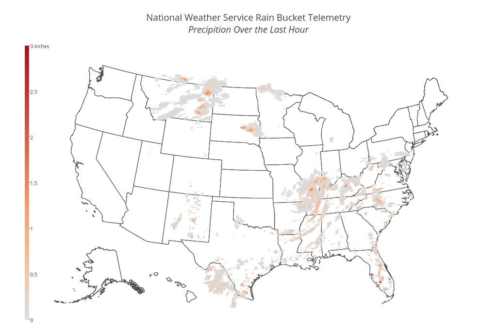

```python
fig = {
    'data':
        [
            {
                'lat': df['Lat'],
                'lon': df['Lon'],
                'marker': {
                    'color': df['Globvalue'],
                    'opacity': 0.7,
                    'size': 2,
                    'cmin': 0,
                    'cmax': 3.0,
                    'colorbar':{
                        'thickness':10,
                        'titleside':"right",
                        'x':0,
                        'y':0.5,
                        'outlinecolor':"rgba(68, 68, 68, 0)",
                        'ticks':"outside",
                        'ticklen':3,
                        'showticksuffix':"last",
                        'ticksuffix':" inches",
                        'dtick': 0.5
                    },
                },
                'type': 'scattergeo'
            }
        ],
    'layout': {
        'geo': {
            'scope': 'usa',
            'resolution': '50' # highest resolution for images
        },
        'margin': {
            'l': 50,
            'r': 0,
            'b': 20
        },
        'title': 'National Weather Service Rain Bucket Telemetry<br><i>Precipition Over the Last Hour</i>',
        'titlefont': {
            'size': 22
        }
    }
}

py.image.ishow(fig, width=1200, height=800)
```

```python
rainiest = df[-10000:]

fig['data'][0].update({
    'lat': rainiest['Lat'],
    'lon': rainiest['Lon'],
    'text': rainiest['Globvalue'].apply(lambda r: str(r)+' inches'),
    'name': ''
})

fig['data'][0]['marker'].update({
    'color': rainiest['Globvalue']
})

fig['layout']['title'] = 'National Weather Service Rain Bucket Telemetry<br>'+\
                         '<i>Rainiest 10k Locations Over the Last Hour</i>'

fig['layout']['geo'].pop('resolution', None) # lower resolution for interactivity


py.iplot(fig, filename='maps/NWS - Rainest 10k', validate=False)
```

[interactive chart not shown]